# Tarea 2 - Representación de Soluciones

## **b) Representación de soluciones**

- **El esquema de representación de soluciones es el siguiente:** Sea $G(V,E)$ una gráfica con vértices $V=\{1,2,\cdots,n\}$ y conjunto de aristas $E =\{ \{i,j\} | \;\text{p.a}\; i,j\in V \}$. Sea $\mathcal C =\{0,1,\cdots,m - 1\}$ un conjunto de colores, definimos una coloración de la gráfica como $x\in \mathbb N^n$ tal que $x_i\in \mathcal C\quad\forall i \in V$. Es decir, cada vértice de la gráfica está asociado a un único índice $i$ tal que $x_i$ representa un color en $\mathcal C$.
- **Justificación de la elección.** El esquema propuesto corresponde a una representación intuitiva y fácil de implementar, pues basta con mostrar una lista de longitud $n$ para entender, sin ambigüedad, la coloración de cada uno de los vértices.
- **Características de la representación:**
  1. **El tamaño del espacio de búsqueda** está dado por $m^n$, ya que cada posibilidad de los $m$ colores puede ser tomada por cada uno de los $n$ vértices.
  2. **La representación es directa** ya que a cada vértice $i$ le corresponde un único color $x_i$.
  3. **La representación es lineal** ya que la asociación de cada color $x_i$ se asigna de forma secuencial sobre el vértice $i$.
  4. **El tipo de mapeo es uno a uno** ya que cada casilla está asociada a un único vértice.
  5. **La factibilidad de las soluciones** no se garantiza para cualquier representación y es necesario iterar sobre el conjunto $E$ para determinar si la solución es factible.
  6. **La representación es completa** pues cualquier combinación de colores de la gráfica puede ser representada en una lista unidireccional.

En el archivo `src/python/graph.py` se encuentran las clases `Vertex`, `Graph` y `Color` las cuales son implementaciones que, en conjunto, forman constituyen la representación de soluciones de coloración de gráficas que fue descrita anteriormente.

- **Vertex**: Esta clase representa un vértice$v \in V$ de la gráfica $G$. Cada vértice tiene un indice `i` ($i\in V$) y una lista de aristas con los índices de los vértices adyacentes. La clase perite añadir vértice adyacente a la lista, asegurándose de no agregar el mismo vértice dos veces y sin formar bucles.
- **Graph**: Esta clase representa una gráfica $G$ con un tamaño dado y una lista opcional de aristas. Al inicializarse, se crea una lista de vértices de un tamaño previamente dado, donde cada vértice es una instancia de la clase `Vertex`. Las aristas son agregados a los vértices correspondientes.
- **Color**: Esta clase se utiliza para representar una coloración $x\in \mathcal C$ de vértices $v\in V$ en una gráfica $G$. Al inicializarse puede generar una coloración aleatoria o determinista, las soluciones pueden ser no triviales si se especifica. La instancia de la clase puede saber si es una solución válida o no.

El pseudocódigo de las clases es el siguiente:

```
Clase Vertex:
    Función init(i):
        self.i = i
        self.edge = conjunto()

    Función add(j):
        Si j ≠ self.i entonces
            self.edge.agregar(j)


Clase Graph:
    Función init(size, edges=conjunto()):
        self.size = size
        self.vertex = lista()
        Para cada i en rango(1, size + 1) hacer
            self.vertex.agregar(Vertex(i))
        Si edges no está vacío entonces
            Para cada i, j en edges hacer
                self.vertex[i-1].add(j)
                self.vertex[j-1].add(i)


Clase Color:
    Función init(graph, size=None, shuffle=Verdadero, notrivial=Falso, colors=None):
        size = graph.size si size es Ninguno sino size
        self.colors = (solution_generation(graph, size, shuffle, notrivial)
                    si colors es Ninguno sino colors)
        self.weight = solution_evaluation(graph, self.colors)
        self.graph = graph
        self.size = size

    Función solution_generation(graph, size, shuffle, notrivial):
        Si notrivial entonces
            colors = lista de -1 * tamaño graph.size
            colorset = lista de i para i en rango(size)
            mezclar(colorset) si shuffle sino None
            Para cada i, vertex en enumerar(graph.vertex) hacer
                Para cada col en colorset hacer
                    available = Verdadero
                    Para cada j en vertex.edge hacer
                        Si colors[j-1] == col entonces
                            available = Falso
                            Romper el bucle
                    Si available entonces
                        colors[i] = col
                        Romper el bucle
                Si colors[i] == -1 entonces
                    colors[i] = 0
            Devolver colors
        Devolver lista de entero aleatorio entre 0 y size - 1 para i en rango(graph.size) si shuffle sino i

    Función solution_evaluation(graph, colors):
        multiplicity = 0
        Para cada i, vertex en enumerar(graph.vertex) hacer
            Para cada j en vertex.edge hacer
                Si colors[i] == colors[j-1] entonces
                    multiplicity += 1
        Devolver longitud de conjunto de colors si multiplicity == 0 sino longitud de colors + multiplicity // 2

    Función neighborhood(epsilon=1):
        neighbors = lista()
        Si epsilon > 0 entonces
            Para cada e en rango(-epsilon, 1 + epsilon) hacer
                Si e ≠ 0 entonces
                    Para cada i en rango(longitud de self.colors) hacer
                        colors = copia de self.colors
                        colors[i] = (colors[i] + e) % self.size
                        neighbors.agregar(Color(graph=self.graph,
                                                size=self.size,
                                                colors=colors))
        Devolver neighbors
```

## **c) Evaluación de soluciones**

La función `solution_evaluation` es una implementación estática de la clase `Color` que recorre cada uno de los vértices y contabiliza la cantidad de veces que hay una coloración idéntica para dos vértices adyacentes (conflictos). Si la solución es factible devuelve la cantidad de colores únicos de lo contrario devuelve $n + \text{# de conflictos}$. De esta forma una solución no factible tendrá una calificación estrictamente mayor que cualquier solución factible. Note que esta implementación también permite clasificar a las soluciones no factibles.

## **d) Soluciones aleatorias**

La función `solution_generation` es una implementación estática de la clase `Color` que permite generar soluciones aleatorias con base en el tamaño de la gráfica y la cantidad de colores. La función genera $n$ valores aleatorios del conjunto $\mathcal C$ y los guarda en una lista. Si se especifica, función permite también garantizar la factibilidad de la solución verificando que no haya vértices con el mismo color antes de guardar el color correspondiente. Se puede cancelar la opcion de aleatoriedad y formar soluciones deterministas.

## **e) Operador de vecindad**

La función `neighborhood` es una implementación propia de las instancias de la clase `Color`, permite generar una vecindad agujereada de radio $\varepsilon$, para esto se defina la suma en $\mathcal C$ como $a+b := mod(a + b, \; m)$, en otras palabras, para generar un vecino a partir de una coloración dada se suma (o resta) $\varepsilon$ módulo $m$ en alguna de las entradas $x_i$ de la solución $x$. La función devuelve a todos los vecinos de la instancia rádio $\varepsilon$.

## **f) Ejemplo**

```python
import matplotlib.colors as mcolors
colores10 = np.array([mcolors.to_hex(color) for color in plt.cm.tab10.colors])
colores20 = np.array([mcolors.to_hex(color) for color in plt.cm.tab20.colors])
random.seed(77)
```

**Ejemplar 1**

```python
size, aristas = leer_ejemplar('data/Ejemplar1.col')
```

```
## >c Ejemplar #1
```

```python
graph = Graph(size, aristas)
color = Color(graph, shuffle=True)
print(f'Representación:\n{graph}')
```

```
## Representación:
## 1: {(1, 2), (1, 5), (1, 4), (1, 7), (1, 6), (1, 3)}
## 2: {(2, 4), (2, 1), (2, 7), (2, 3), (2, 6), (2, 5)}
## 3: {(3, 4), (3, 1), (3, 7), (3, 6), (3, 2), (3, 5)}
## 4: {(4, 1), (4, 2), (4, 3)}
## 5: {(5, 3), (5, 1), (5, 2)}
## 6: {(6, 1), (6, 2), (6, 3)}
## 7: {(7, 1), (7, 2), (7, 3)}
```

```python
print(f'Coloración aleatoria:\n{color}')
```

```
## Coloración aleatoria:
## [6, 2, 2, 1, 1, 1, 6]
```

```python
print(f'Evaluación de solución:\n{color.weight}')
```

```
## Evaluación de solución:
## 9
```

```python
neighbors = '\n'.join([f'{i}: {c}'
    for i, c in enumerate(color.neighborhood())])
print(f'Vencindad de rádio épsilon = 1:\n{neighbors}')
```

```
## Vencindad de rádio épsilon = 1:
## 0: [5, 2, 2, 1, 1, 1, 6]
## 1: [6, 1, 2, 1, 1, 1, 6]
## 2: [6, 2, 1, 1, 1, 1, 6]
## 3: [6, 2, 2, 0, 1, 1, 6]
## 4: [6, 2, 2, 1, 0, 1, 6]
## 5: [6, 2, 2, 1, 1, 0, 6]
## 6: [6, 2, 2, 1, 1, 1, 5]
## 7: [0, 2, 2, 1, 1, 1, 6]
## 8: [6, 3, 2, 1, 1, 1, 6]
## 9: [6, 2, 3, 1, 1, 1, 6]
## 10: [6, 2, 2, 2, 1, 1, 6]
## 11: [6, 2, 2, 1, 2, 1, 6]
## 12: [6, 2, 2, 1, 1, 2, 6]
## 13: [6, 2, 2, 1, 1, 1, 0]
```

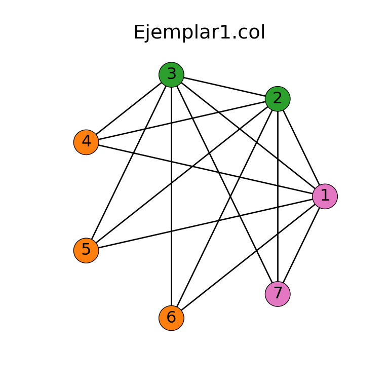

```python
plt.figure(figsize=(4, 4))
plot_graph(size, aristas, colores10[color.colors])
plt.title('Ejemplar1.col')
plt.show()
```

**Ejemplar 2**

```python
size, aristas = leer_ejemplar('data/Ejemplar2.col')
```

```
## >c Ejemplar #2
```

```python
graph = Graph(size, aristas)
color = Color(graph, shuffle=True)
print(f'Representación:\n{graph}')
```

```
## Representación:
## 1: {(1, 12), (1, 14)}
## 2: {(2, 7), (2, 10), (2, 3), (2, 6), (2, 5)}
## 3: {(3, 2), (3, 14), (3, 9), (3, 6)}
## 4: {(4, 5), (4, 10), (4, 11), (4, 6)}
## 5: {(5, 4), (5, 2)}
## 6: {(6, 8), (6, 3), (6, 2), (6, 4)}
## 7: {(7, 9), (7, 2)}
## 8: {(8, 9), (8, 11), (8, 6)}
## 9: {(9, 7), (9, 8), (9, 3), (9, 15)}
## 10: {(10, 15), (10, 4), (10, 2)}
## 11: {(11, 8), (11, 4)}
## 12: {(12, 1)}
## 13: {}
## 14: {(14, 1), (14, 3)}
## 15: {(15, 10), (15, 9)}
```

```python
print(f'Coloración aleatoria:\n{color}')
```

```
## Coloración aleatoria:
## [1, 4, 7, 8, 9, 3, 2, 8, 10, 10, 8, 0, 13, 4, 0]
```

```python
print(f'Evaluación de solución:\n{color.weight}')
```

```
## Evaluación de solución:
## 17
```

```python
neighbors = '\n'.join([f'{i}: {c}'
    for i, c in enumerate(color.neighborhood())])
print(f'Vencindad de rádio épsilon = 1:\n{neighbors}')
```

```
## Vencindad de rádio épsilon = 1:
## 0: [0, 4, 7, 8, 9, 3, 2, 8, 10, 10, 8, 0, 13, 4, 0]
## 1: [1, 3, 7, 8, 9, 3, 2, 8, 10, 10, 8, 0, 13, 4, 0]
## 2: [1, 4, 6, 8, 9, 3, 2, 8, 10, 10, 8, 0, 13, 4, 0]
## 3: [1, 4, 7, 7, 9, 3, 2, 8, 10, 10, 8, 0, 13, 4, 0]
## 4: [1, 4, 7, 8, 8, 3, 2, 8, 10, 10, 8, 0, 13, 4, 0]
## 5: [1, 4, 7, 8, 9, 2, 2, 8, 10, 10, 8, 0, 13, 4, 0]
## 6: [1, 4, 7, 8, 9, 3, 1, 8, 10, 10, 8, 0, 13, 4, 0]
## 7: [1, 4, 7, 8, 9, 3, 2, 7, 10, 10, 8, 0, 13, 4, 0]
## 8: [1, 4, 7, 8, 9, 3, 2, 8, 9, 10, 8, 0, 13, 4, 0]
## 9: [1, 4, 7, 8, 9, 3, 2, 8, 10, 9, 8, 0, 13, 4, 0]
## 10: [1, 4, 7, 8, 9, 3, 2, 8, 10, 10, 7, 0, 13, 4, 0]
## 11: [1, 4, 7, 8, 9, 3, 2, 8, 10, 10, 8, 14, 13, 4, 0]
## 12: [1, 4, 7, 8, 9, 3, 2, 8, 10, 10, 8, 0, 12, 4, 0]
## 13: [1, 4, 7, 8, 9, 3, 2, 8, 10, 10, 8, 0, 13, 3, 0]
```

[output cut: 16 more lines]

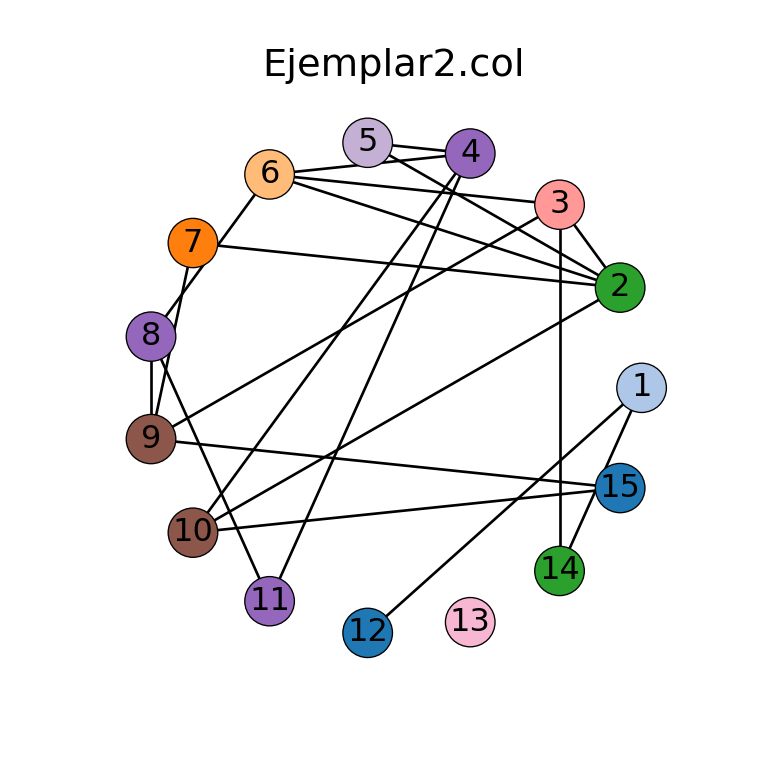

```python
plt.figure(figsize=(4, 4))
plot_graph(size, aristas, colores20[color.colors])
plt.title('Ejemplar2.col')
plt.show()
```

## **h) Búsqueda por escalada**

La función `hill_climbing` del archivo `src/python/graph.py` implementa la búsqueda por escalada una gráfica. A continuación, el pseudogódigo:

```
Función hill_climbing(graph, size=Ninguno, shuffle=Verdadero, notrivial=Falso, colors=Ninguno, epsilon=1, iterations=10000, stop=60):
    color = Color(graph, size, shuffle, notrivial, colors)
    fmin = color.weight
    start = tiempo_actual()
    Para cada iter en rango(iterations):
        Para cada neighbor en color.neighborhood(epsilon):
            Si neighbor.weight < fmin entonces
                color = neighbor
                fmin = color.weight
        Si (tiempo_actual() - start > stop) entonces
            Romper el bucle
    Devolver diccionario con xmin=color.colors, fmin=fmin, iterations=iter+1, seconds=tiempo_actual()-start
```

Ejemplos de uso:

```python
hill_climbing(Graph(*leer_ejemplar('data/ejemplar1.col')))
```

```
## >c Ejemplar #1
##
## {'xmin': [5, 3, 0, 6, 6, 1, 4], 'fmin': 6, 'iterations': 10000, 'seconds': 0.6404685974121094}
```

```python
hill_climbing(Graph(*leer_ejemplar('data/ejemplar2.col')))
```

```
## >c Ejemplar #2
##
## {'xmin': [12, 5, 2, 5, 4, 1, 1, 7, 12, 4, 8, 7, 3, 3, 3], 'fmin': 8, 'iterations': 10000, 'seconds': 2.0019209384918213}
```

```python
hill_climbing(Graph(*leer_ejemplar('data/ejemplar3.col')))
```

```
## >c Ejemplar #3
##
## >c FILE: myciel5.col
##
## >c SOURCE: Michael Trick (trick@cmu.edu)
##
## >c DESCRIPTION: Graph based on Mycielski transformation.
##
## >c              Triangle free (clique number 2) but increasing
##
## >c              coloring number
##
## >c solucion 6
##
## {'xmin': [4, 5, 12, 44, 35, 28, 38, 45, 34, 4, 5, 45, 14, 21, 5, 6, 36, 29, 4, 34, 6, 17, 28, 40, 35, 7, 21, 33, 3, 25, 36, 38, 33, 14, 14, 36, 29, 25, 7, 25, 0, 2, 3, 31, 40, 2, 22], 'fmin': 24, 'iterations': 10000, 'seconds': 39.897536754608154}
```

**Ejecución de ejemplares en terminal:**

`python escalada.py data/Ejemplar1.col`

`python escalada.py data/Ejemplar2.col`

`python escalada.py data/Ejemplar3.col`

# Ejercicio 3. Preguntas de repaso

## **3.1 Problema con representación de soluciones con codificación indirecta**

Definimos la siguiente función, sea $f:\mathbb R^2\rightarrow \mathbb R$ ta que $f(x,y) = |sin(x^2+y^2)|$. Observe que $f$ es una función no negativa que alcanza un mínimo en cero, particularmente, la función se anula siempre que $x^2+y^2 = \pi n$ para algún $n$ entero. En consecuencia, las circunferencias en $\mathbb R^2$ con centro en $(0,0)$ y de radio $\sqrt{\pi n}$ son una codificación indirecta para las soluciones óptimas de $f$:

$$\mathcal C_{\sqrt{\pi n}} = \left\lbrace
\left.(x,y)\right|x^2+y^2 =\pi n, n\;\forall n\in\mathbb N
\right\rbrace$$

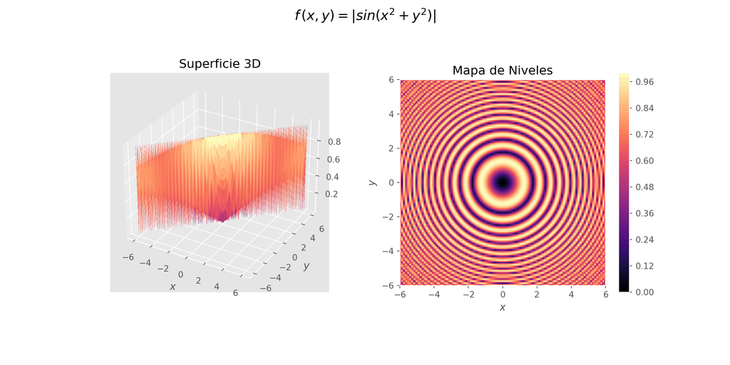

- **Observación:** La codificación es indirecta ya que da una regla para describir las soluciones, pero no las muestra de forma explícita. Note que es posible generalizar la codificación para particionar el espacio $\mathbb R^2$ en regiones independientes y ordenadas mediante los conjuntos:

$$\mathcal C_{k} = \left\lbrace
\left.(x,y)\right|x^2+y^2 =k^2 \right\rbrace$$

## **3.2 Problemas de optimización combinatoria**

### **a.** *Problema de la Mochila Binaria (Binary Knapsack Problem)*

*“… un excursionista tiene que llenar su mochila seleccionando entre varios objetos posibles aquellos que le darán el máximo confort.”* [S. Martello, 1990]

### **b.** *Problema de Programación de Tareas (Job Scheduling Problem)*

En este problema, se deben asignar $n$ tareas a $m$ trabajadores, donde cada tarea tiene un tiempo de procesamiento y cada trabajador puede realizar una sola tarea a la vez. El objetivo es minimizar el tiempo total de finalización del total de tareas asignadas. [L. Pinedo, 2012]

*Representación con vector de valores discretos*

- **El espacio de búsqueda:** El espacio de búsqueda consiste en todas las posibles asignaciones de $n$ tareas a $m$ trabajadores, es decir $S = \{1, 2, ..., m\}^n$, el índice de las soluciones representa la tarea a realizar y el valor de cada entrada hace referencia al trabajador asignado a dicha tarea.
- **La función objetivo:** La función objetivo es minimizar el tiempo total que lleva la finalización de todas las tareas, entonces, $f(x) = \max \left\lbrace \sum_{i=1}^n p_i x_{ij}\right\rbrace_{j=1}^m$, donde $x_{ij}$ indica si la tarea $i$ fue asignada al trabajador $j$.
- **Tamaño del espacio de búsqueda:** Cada tarea tiene $m$ posibilidades para ser realizada, por lo que el tamaño de el espacio de búsqueda está dato por $m^n$.
- **Ejemplar concreto del problema:** Supongamos que tenemos 3 tareas ($n = 3$) y 2 trabajadores ($m = 2$). Las tareas tienen los siguientes tiempos de realización $p_1 = 2$, $p_2 = 4$, $p_3 = 1$.
- **Ejemplo de una solución, codificada con la representación correspondiente:** Una solución al problema es $x = (1, 2, 1)$, lo que indica que las tareas $1$ y $3$ son asignadas al trabajador $1$ mientras que la tarea 2 la realizará el trabajador $2$. El tiempo de realización del total de las tareas es $\max(2 + 1,\, 4) = 4$.
- **¿Qué tipo de mapeo induce la representación?** La representación con vector de valores discretos induce un mapeo “uno a uno” ya que cada tarea está asociada a un índice en el vector de soluciones y cada tarea es asignada a un único trabajador.
- **Observaciones:** El problema parece ser una generalización del problema de la mochila, incluso se requiere de la misma cantidad de bits para almacenar sus soluciones. De igual forma es fácil de visualizar por su representación lineal y directa. La generación de soluciones vecinas puede llevarse a cabo sumando o restando valores en cada una de las casillas lo que tiene el significado asignar la tarea a otro trabajador.

### **c.** *Problema de Enrutamiento de Vehículos (Vehicle Routing Problem)*

*“Determinar un conjunto de rutas de vehículos para realizar todas (o algunas) las solicitudes de transporte con la flota de vehículos dada al menor costo posible; en particular, decidir qué vehículo maneja qué solicitudes en qué secuencia para que todas las rutas de vehículos puedan ser ejecutadas de manera factible.”* [P. Toth & D. Vigo, 2014]

*Representación con codificación de permutaciones*

- **El espacio de búsqueda:** Consiste en la elección de $m$ permutaciónes de dimensión $n$ cada una, entonces $S = (\mathcal P_n )^m$, donde $\mathcal P_n$ es el espacio de permutaciones de $n$ elementos, $n$ es el número de solicitudes y $m$ la cantidad de vehículos disponibles.
- **La función objetivo:** Minimizar $f(x) = \sum_{k=1}^{m} \sum_{(i,j)} c_{ij} \cdot x_{ijk}$, donde $c_{ij}$ es el costo de viaje desde el cliente $i$ al cliente $j$ y $x_{ijk}$ es una variable binaria que indica si el vehículo $k$ viaja desde el cliente $i$ al cliente $j$.
- **Tamaño del espacio de búsqueda:** El espacio de permutaciones tiene dimensión $n!$, cada cada permitación tiene $m$ posibilidades, por lo tanto, el tamaño del espacio de búsqueda es $n!^m$.
- **Ejemplar concreto del problema:** Suponga que se tienen dos vehículos y cinco destinos, es necesario recoger un cargamento de $2u$, $2u$, $5u$, $3u$ y $6u$ en cada destino respectivamente. La capacidad máxima de cada vehículo es de $10u$, todos los vehículos tienen que regresar al destino $(1)$, el costo de trasladarse de destino $(i)$ al destino $(j)$ es de $|i-j|$.
- **Ejemplo de una solución, codificada con la representación correspondiente:** Una solución para el problema es $x = ((1,2,4,5), (1,3,5))$, es decir el primer vehículo toma la ruta $1\to2\to4\to5\to1$ y el segundo $1\to3\to5\to1$, una opci+omn factible para el cargamento de los vehículos es $((2u,2u,3u,1u),(0u,5u,5u))$. El costo de la solución está dado por $(|2-1|+|4-2|+|5-4|+|1-5|) +(|3-1|+|5-3|+|1-5|) = 16$
- **¿Qué tipo de mapeo induce la representación?** El mapeo es de “muchos a muchos”, por un lado, existen múltiples codificaciones para una única permutación, retomando el ejemplar anterior, las siguientes representaciones corresponden a la misma solución $((1,2,4,5), (1,3,5)) = ((5,1,2,4), (3,5,1))$ (siempre y cuando se asuma que los vehículos recogen el mismo cargamente en su respectiva representación), sin embargo, el mismo recorrido de rutas puede corresponder a más de una solución si los vehículos modifican sus cargamentos. Por ejemplo, las siguientes opciones de cargamento son distintas y están asociadas a la misma representación de solución: $((2u,2u,3u,1u),(0u,5u,5u)) \neq ((1u,2u,3u,2u),(1u,5u,4u))$.
- **Observaciones:** El problema del enrutamiento de vehículos, me parece el más complejo de todos los vistos por su gran cantidad de posibilidades. Tiene una representación directa, pero no lineal ya que cada solución es una serie de $m$ operadores sobre un producto carteciano. La generación de soluciones basadas en una inicial pudiera darse eliminando nodos de alguna permutación y agregarlos en una permutación vecina.

# Referencias

```
[1] Silvano Martello.
Knapsack Problems: Algorithms and Computer Implementations.
John Wiley & Sons, 1990.

[2] Michael L. Pinedo.
Scheduling: Theory, Algorithms, and Systems.
Springer, 2012.

[3] Paolo Toth and Daniele Vigo.
Vehicle Routing: Problems, Methods, and Applications.
SIAM, 2014.
```